# Exploratory Data Analysis on Quality of Red Wine

Alcohol, Sulphates & volatile acidity account for most variation in the quality.

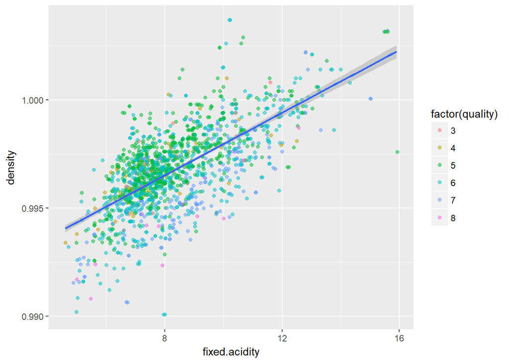

we can see the relationship between fixed acidity and density with points colored with respect to quality.

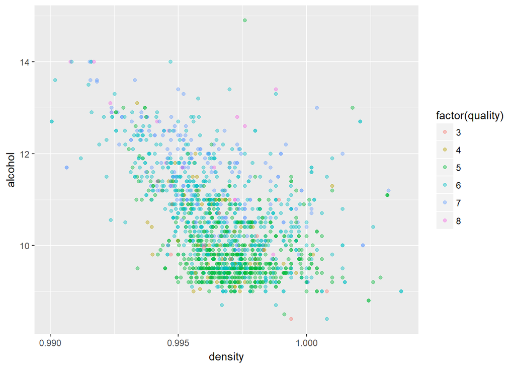

scatterplot of alcohol over density with points colored with respect to quality.

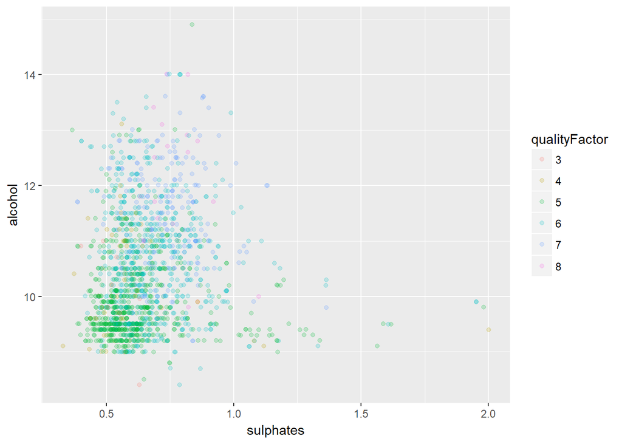

scatterplot of alcohol over sulphates with points colored with respect to quality.

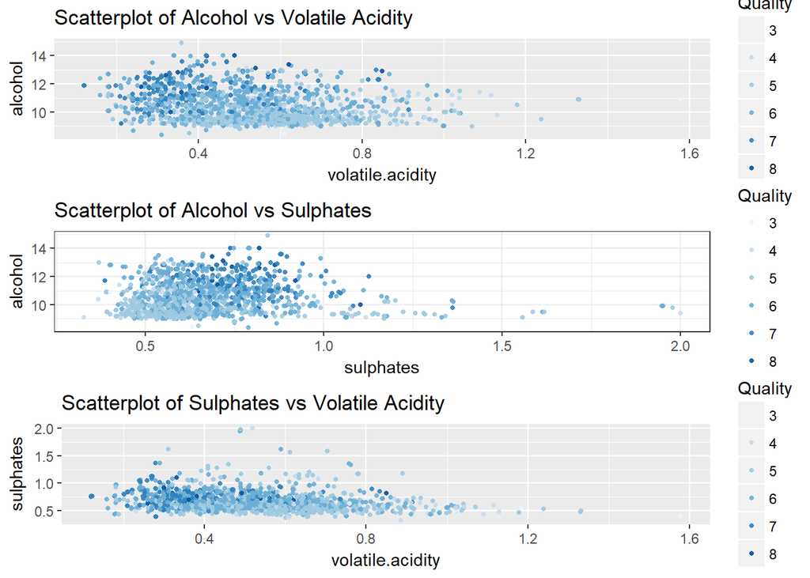

Looking at the variation from the correlation test and multiple linear regression I have created the above plots to look for the relationship between quality and other chemical properties. These plots are discussed in detail below.

# Multivariate Analysis:

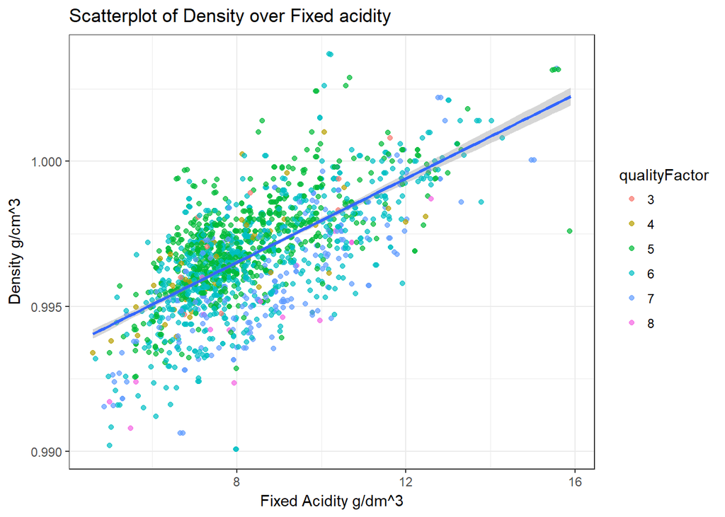

Here we can see that for a given value of Fixed Acidity the lower density generally tends to yeild a better quality of wine.

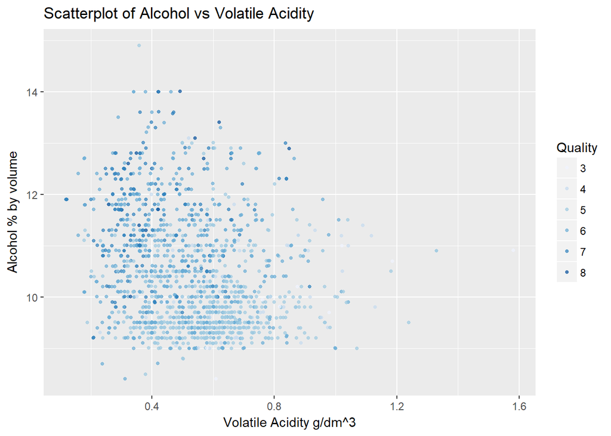

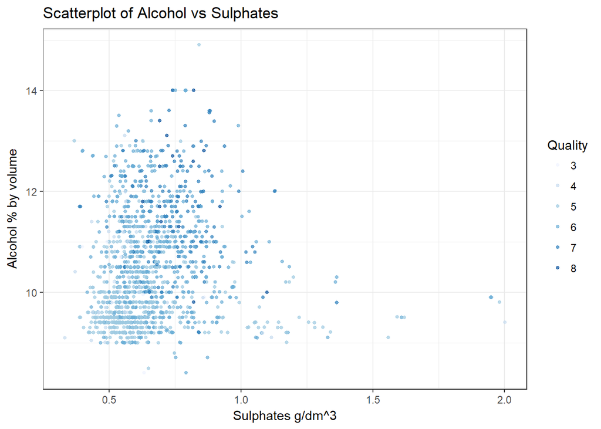

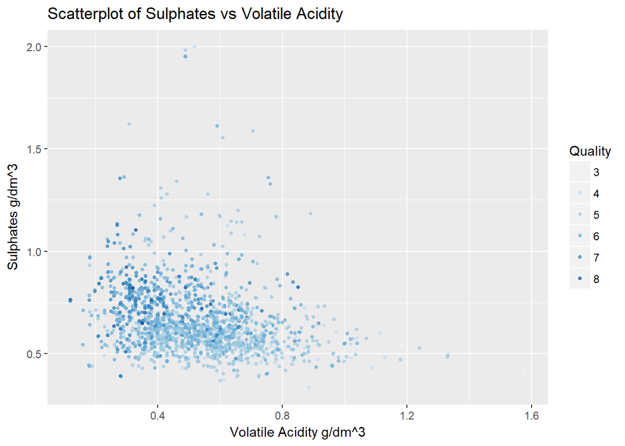

This graph revalidates our claim that quality is somewhat linearly related to **Alcohol & Sulphates** and inversely related to **Volatile Acidity**

We can see that for first plot the quality increases with Alcohol and decreases with Volatile Acidity.

In Second plot Quality increases with Alcohol and sulphates.

Thrid plot it Increases with sulphates and decreases with Volatile Acidity.

# Final Plots & Summary

There are many interesting plots that we have come across during the analysis of redwine sample dataset.

But these plots have helped us answer the question that we have raised at the beginning regarding the quality of red wine.

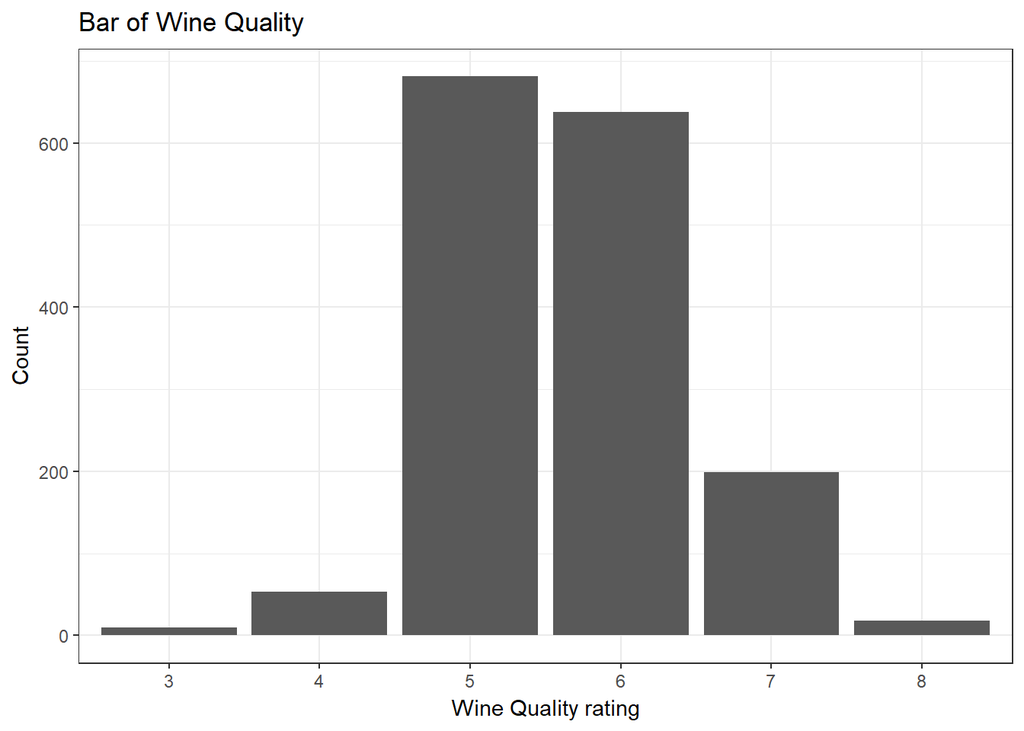

This plot helped us see that there are many medium quality red wines in our sample data set and the lowest rated quality sample is 3 and the highest rated quality sample is 8. There are no redwines with highest quality rating 10 or lowest quality rating 0.

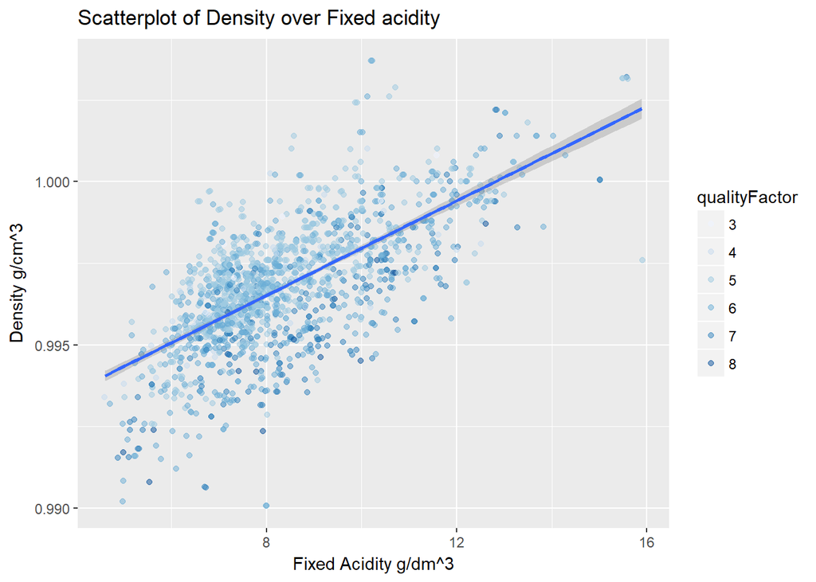

The density and fixed acidity have a linear relationshio among them and these are most related in our data set. interesting enough we can see that the quality for a value of Fixed acidity decreases with an increase in density.

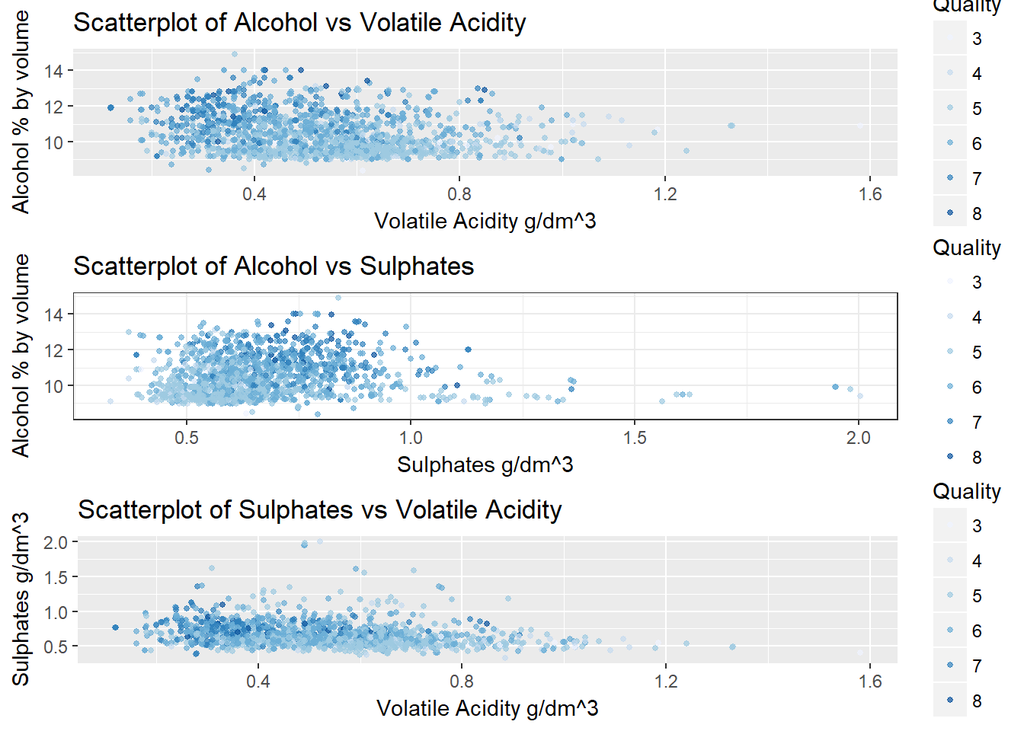

This plot helps to potray the chemical properties with strong/weak relationship to quality in our sample data set of red wines.

As we have found before __ % of Alcohol and amount of sulphates__ present in redwine tend to have positve relationship with quality of redwine. whereas **Amt of Volatile Acidity** tends to have inverse relationship with quality of red wine.

```
##
## Calls:
## m1: lm(formula = quality ~ alcohol, data = redWine)
## m2: lm(formula = quality ~ alcohol + log10(sulphates), data = redWine)
## m3: lm(formula = quality ~ alcohol + log10(sulphates) + volatile.acidity,
##     data = redWine)
## m4: lm(formula = quality ~ alcohol + log10(sulphates) + volatile.acidity +
##     log10(residual.sugar), data = redWine)
## m5: lm(formula = quality ~ alcohol + log10(sulphates) + volatile.acidity +
##     log10(residual.sugar) + log10(chlorides), data = redWine)
## m6: lm(formula = quality ~ alcohol + log10(sulphates) + volatile.acidity +
##     log10(residual.sugar) + log10(chlorides) + log10(free.sulfur.dioxide1),
##     data = redWine)
## m7: lm(formula = quality ~ alcohol + log10(sulphates) + volatile.acidity +
##     log10(residual.sugar) + log10(chlorides) + log10(free.sulfur.dioxide1) +
##     log10(total.sulfur.dioxide1), data = redWine)
## m8: lm(formula = quality ~ alcohol + log10(sulphates) + volatile.acidity +
##     log10(residual.sugar) + log10(chlorides) + log10(free.sulfur.dioxide1) +
##     log10(total.sulfur.dioxide1) + density, data = redWine)
## m9: lm(formula = quality ~ alcohol + log10(sulphates) + volatile.acidity +
##     log10(residual.sugar) + log10(chlorides) + log10(free.sulfur.dioxide1) +
##     log10(total.sulfur.dioxide1) + density + pH, data = redWine)
## m10: lm(formula = quality ~ alcohol + log10(sulphates) + volatile.acidity +
##     log10(residual.sugar) + log10(chlorides) + log10(free.sulfur.dioxide1) +
##     log10(total.sulfur.dioxide1) + density + pH, data = redWine)
## m11: lm(formula = quality ~ alcohol + log10(sulphates) + volatile.acidity +
##     log10(residual.sugar) + log10(chlorides) + log10(free.sulfur.dioxide1) +
##     log10(total.sulfur.dioxide1) + density + pH + citric.acid,
##     data = redWine)
##
## ==========================================================================================================================================================================================
##                                      m1            m2            m3            m4            m5            m6            m7            m8            m9           m10           m11
## ------------------------------------------------------------------------------------------------------------------------------------------------------------------------------------------
##   (Intercept)                       1.875***      2.541***      3.369***      3.377***      3.062***      3.314***      3.923***     -1.636         8.747         8.747        -1.210
##                                    (0.175)       (0.177)       (0.184)       (0.185)       (0.202)       (0.270)       (0.304)      (12.737)      (12.929)      (12.929)      (14.041)
##   alcohol                           0.361***      0.335***      0.303***      0.304***      0.282***      0.279***      0.260***      0.266***      0.271***      0.271***      0.287***
##                                    (0.017)       (0.016)       (0.016)       (0.016)       (0.017)       (0.017)       (0.017)       (0.021)       (0.021)       (0.021)       (0.023)
##   log10(sulphates)                                2.070***      1.477***      1.478***      1.714***      1.738***      1.788***      1.766***      1.770***      1.770***      1.778***
##                                                  (0.177)       (0.177)       (0.177)       (0.187)       (0.188)       (0.187)       (0.194)       (0.193)       (0.193)       (0.193)
##   volatile.acidity                                             -1.156***     -1.154***     -1.100***     -1.097***     -1.074***     -1.071***     -0.952***     -0.952***     -1.064***
```

[output cut: 12 more lines]

```
##                                                                                                                                                    (0.119)       (0.119)       (0.133)
##   citric.acid                                                                                                                                                                  -0.245
##                                                                                                                                                                                (0.135)
## ------------------------------------------------------------------------------------------------------------------------------------------------------------------------------------------
##   R-squared                         0.227         0.288         0.345         0.346         0.352         0.352         0.360         0.360         0.366         0.366         0.368
##   adj. R-squared                    0.226         0.287         0.344         0.344         0.350         0.350         0.357         0.356         0.363         0.363         0.364
##   sigma                             0.710         0.682         0.654         0.654         0.651         0.651         0.648         0.648         0.645         0.645         0.644
##   F                               468.267       322.031       280.646       210.397       172.715       144.349       127.638       111.651       102.059       102.059        92.313
##   p                                 0.000         0.000         0.000         0.000         0.000         0.000         0.000         0.000         0.000         0.000         0.000
##   Log-likelihood                -1721.057     -1655.601     -1587.752     -1587.693     -1580.332     -1579.336     -1570.300     -1570.204     -1561.907     -1561.907     -1560.257
##   Deviance                        805.870       742.522       682.108       682.058       675.807       674.965       667.380       667.300       660.410       660.410       659.049
##   AIC                            3448.114      3319.202      3185.503      3187.386      3174.664      3174.671      3158.600      3160.409      3145.814      3145.814      3144.513
##   BIC                            3464.245      3340.711      3212.389      3219.649      3212.304      3217.688      3206.994      3214.180      3204.962      3204.962      3209.039
##   N                              1599          1599          1599          1599          1599          1599          1599          1599          1599          1599          1599
## ==========================================================================================================================================================================================
```

I have perfromed a multiple regression on all the available chemical properties againts quality to find which chemical properties offer maximum variance i.e., r^2 value interesting enough i found that Alcohol, volatile acidity and sulphates offer upto 34.5% variance and the overall value of r^2 is 36.8% which indicates that the other chemical properties govern little variance of quality.

This answers over question earlier that properties Alcohol, volatile acidity and sulphates account for quality of redwine but these have a very small influence over the rating of redwine none the less offer something when compared to other chemical properties.

# Reflection:

As the first data set available in the projects page I found myself tending towrds this one. And it was taking about redwine of which I have heard plenty of healthy benifits about and I myself started drinking in right does to get the benifits. so, i was interested about what chemical properties are in redwine and how they all govern quality.

EDA module in udacity and problem sets for analysis of univariate, bivariate and multivariate variables availabe in our data set made me familiar with the process of exploratory data analysis.

when I initially started looking at the data and performed univariate analysis nothing excited me than I was not understanding anything. I later tracked back to basics that I have to get familiar with documentation then can figure out whats happening with the variables.

This helped me and those graphs started making sense. Another tricky part was that I thought there will be a clear relationship with chemical properties and quality expect few but that was not the case. then realized whats said in theory only reflects a bit practically.

When I have drawn scatterplot for chemical properties with high correlation coefficient the graphs were not showing a trend I was expecting than I figured out that boxplot will help showing the relationship.

I have initially missed that quality is ordinal and i have to use sequential color pallete and bar plot is used to dipict an ordinal variable.

I feel like everything was straight forward except finding the relationship. programming with r is simple and easy thanks to practice problem sets.